# Classification

### Feature Selection

```r
library(randomForest)
fit=randomForest(Loan_Status ~ . , data= dataADASYN)
```

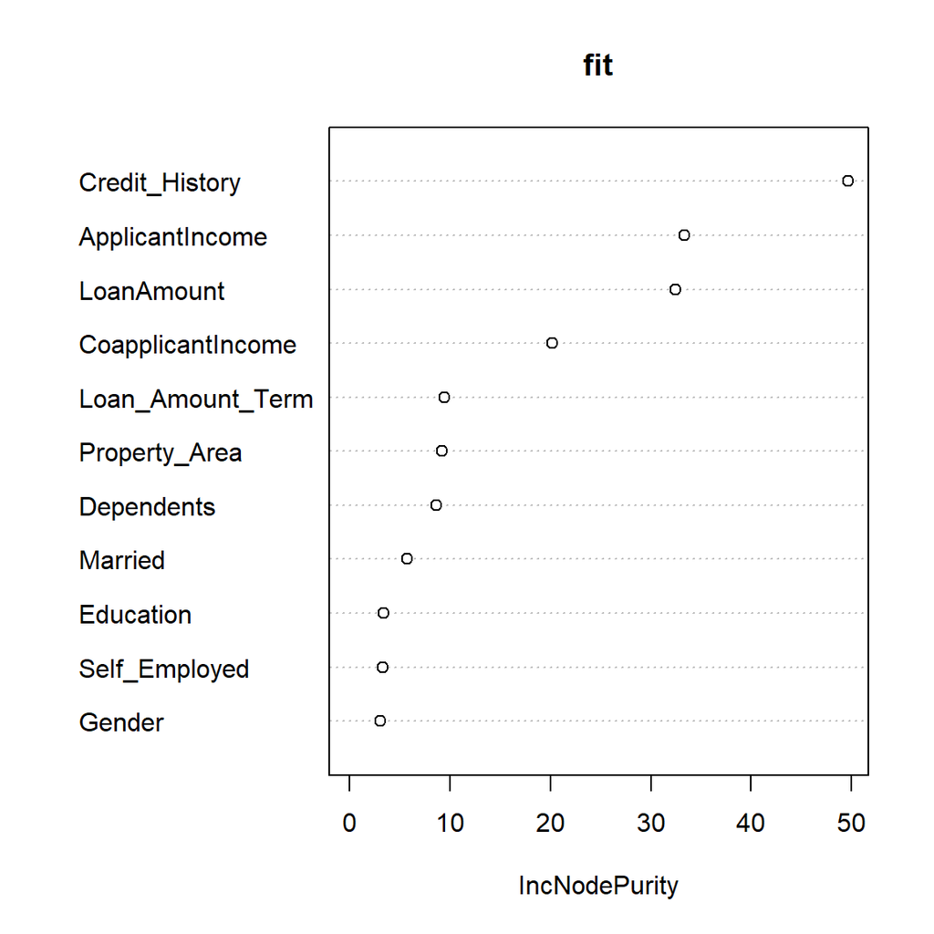

```r
varImpPlot(fit,type=2)
```

```r
dataset = dataMWMOTE
dataset2 = dataMWMOTE[,c('Loan_Status','Credit_History','ApplicantIncome','LoanAmount','CoapplicantIncome')]
```

# 4.1 Modelling

Pada 4.1 ini kita akan gunakan seluruh data, tanpa mempertimbangkan hasil seleksi fitur

Kita akan menggunakan *k-fold cross validation*

```r
# Set seed untuk menghasilkan keacakan yang sama
set.seed(123)

# Tentukan cross validation berulang dengan 10 folds/lipatan dan satu pengulangan
evaluationSetting <- trainControl(method='repeatedcv',
                                  number=10,
                                  repeats=1,
                                  # Evaluate performance using
                                  # the following function summaryFunction
                                  summaryFunction = multiClassSummary)

metric <- "Accuracy"
```

## Decision Tree

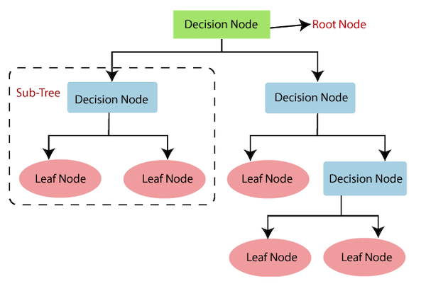

Decision Tree (image source: https://glints.com)

Classification and Regression Tree (CART)

```r
DT_Model <- caret::train(factor(Loan_Status)~.,
                    data=dataset,
                    method="rpart",
                    # metric=metric,
                    # tuneGrid = expand.grid(cp = seq(0, 0.1, 0.001)),
                    # parms = list(split='information'),
                    trControl=evaluationSetting)
print(DT_Model)
```

```
## CART
##
## 823 samples
##  11 predictor
##   2 classes: '1', '2'
##
## No pre-processing
## Resampling: Cross-Validated (10 fold, repeated 1 times)
## Summary of sample sizes: 740, 741, 740, 741, 741, 741, ...
## Resampling results across tuning parameters:
##
##   cp          Accuracy   Kappa      F1         Sensitivity  Specificity
##   0.01995012  0.7788128  0.5533876  0.7246086  0.6057927    0.9430233
##   0.02119701  0.7739641  0.5430069  0.7105805  0.5807927    0.9571982
##   0.53615960  0.6307670  0.2459719  0.6596047  0.2500000    0.9928571
##   Pos_Pred_Value  Neg_Pred_Value  Precision  Recall     Detection_Rate
##   0.9178009       0.7185390       0.9178009  0.6057927  0.2952542
##   0.9371680       0.7097009       0.9371680  0.5807927  0.2831178
##   0.9722567       0.5938401       0.9722567  0.2500000  0.1216721
##   Balanced_Accuracy
##   0.7744080
##   0.7689955
##   0.6214286
##
## Accuracy was used to select the optimal model using the largest value.
## The final value used for the model was cp = 0.01995012.
```

## Logistic Regression

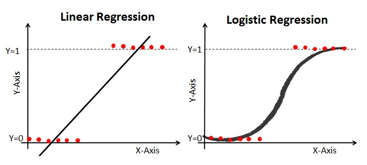

Logistic Regression (image source: https://www.lapthrinhx.com)

```r
RegLog_Model <- caret::train(factor(Loan_Status)~.,
                    data=dataset,
                    method="glm",
                    family = 'binomial',
                    # metric=metric,
                    trControl=evaluationSetting)
print(RegLog_Model)
```

```
## Generalized Linear Model
##
## 823 samples
##  11 predictor
##   2 classes: '1', '2'
##
## No pre-processing
## Resampling: Cross-Validated (10 fold, repeated 1 times)
## Summary of sample sizes: 741, 740, 740, 741, 741, 741, ...
## Resampling results:
##
##   Accuracy   Kappa     F1         Sensitivity  Specificity  Pos_Pred_Value
##   0.7728916  0.541993  0.7242259  0.6159756    0.9220377    0.8872329
##   Neg_Pred_Value  Precision  Recall     Detection_Rate  Balanced_Accuracy
##   0.7176566       0.8872329  0.6159756  0.3001616       0.7690066
```

## Support Vector Machine (SVM)

```r
SVM_Model <- caret::train(factor(Loan_Status)~.,
                    data=dataset,
                    method="svmRadial",
                    # metric=metric,
                    trControl=evaluationSetting)
print(SVM_Model)
```

```
## Support Vector Machines with Radial Basis Function Kernel
##
## 823 samples
##  11 predictor
##   2 classes: '1', '2'
##
## No pre-processing
## Resampling: Cross-Validated (10 fold, repeated 1 times)
## Summary of sample sizes: 741, 741, 741, 741, 740, 741, ...
## Resampling results across tuning parameters:
##
##   C     Accuracy   Kappa      F1         Sensitivity  Specificity
##   0.25  0.7826116  0.5601091  0.7151337  0.5710976    0.9834994
##   0.50  0.7862117  0.5680314  0.7294285  0.6010366    0.9620709
##   1.00  0.7874460  0.5707464  0.7343021  0.6135366    0.9526024
##   Pos_Pred_Value  Neg_Pred_Value  Precision  Recall     Detection_Rate
##   0.9683083       0.7097532       0.9683083  0.5710976  0.2783360
##   0.9387220       0.7200602       0.9387220  0.6010366  0.2929117
##   0.9271550       0.7251017       0.9271550  0.6135366  0.2990093
##   Balanced_Accuracy
##   0.7772985
##   0.7815537
##   0.7830695
##
## Tuning parameter 'sigma' was held constant at a value of 0.06595254
## Accuracy was used to select the optimal model using the largest value.
## The final values used for the model were sigma = 0.06595254 and C = 1.
```

## Naive Bayes

```r
NB_Model <- caret::train(factor(Loan_Status)~.,
                    data=dataset,
                    method="naive_bayes",
                    # metric=metric,
                    trControl=evaluationSetting)
print(NB_Model)
```

```
## Naive Bayes
##
## 823 samples
##  11 predictor
##   2 classes: '1', '2'
##
## No pre-processing
## Resampling: Cross-Validated (10 fold, repeated 1 times)
## Summary of sample sizes: 741, 741, 740, 741, 740, 740, ...
## Resampling results across tuning parameters:
##
##   usekernel  Accuracy   Kappa      F1         Sensitivity  Specificity
##   FALSE      0.7691302  0.5340551  0.7138691  0.5935976    0.9361019
##    TRUE      0.7910226  0.5776678  0.7323839  0.5910976    0.9811185
##   Pos_Pred_Value  Neg_Pred_Value  Precision  Recall     Detection_Rate
##   0.8980917       0.7086650       0.8980917  0.5935976  0.2891713
##   0.9679456       0.7173344       0.9679456  0.5910976  0.2879665
##   Balanced_Accuracy
##   0.7648497
##   0.7861080
##
## Tuning parameter 'laplace' was held constant at a value of 0
## Tuning
##  parameter 'adjust' was held constant at a value of 1
## Accuracy was used to select the optimal model using the largest value.
## The final values used for the model were laplace = 0, usekernel = TRUE
##  and adjust = 1.
```

## Support Vector Machine (SVM)

```r
SVM_Model <- caret::train(factor(Loan_Status)~.,
                    data=dataset,
                    method="svmRadial",
                    # metric=metric,
                    trControl=evaluationSetting)
print(SVM_Model)
```

```
## Support Vector Machines with Radial Basis Function Kernel
##
## 823 samples
##  11 predictor
##   2 classes: '1', '2'
##
## No pre-processing
## Resampling: Cross-Validated (10 fold, repeated 1 times)
## Summary of sample sizes: 741, 741, 741, 740, 741, 740, ...
## Resampling results across tuning parameters:
##
##   C     Accuracy   Kappa      F1         Sensitivity  Specificity
##   0.25  0.7825301  0.5601551  0.7168679  0.5710976    0.9834994
##   0.50  0.7873788  0.5704901  0.7310379  0.6010366    0.9644518
##   1.00  0.7922274  0.5806048  0.7416398  0.6185366    0.9573643
##   Pos_Pred_Value  Neg_Pred_Value  Precision  Recall     Detection_Rate
##   0.9690437       0.7083214       0.9690437  0.5710976  0.2782692
##   0.9405356       0.7197303       0.9405356  0.6010366  0.2928445
##   0.9308689       0.7269044       0.9308689  0.6185366  0.3013517
##   Balanced_Accuracy
##   0.7772985
##   0.7827442
##   0.7879505
##
## Tuning parameter 'sigma' was held constant at a value of 0.0668052
## Accuracy was used to select the optimal model using the largest value.
## The final values used for the model were sigma = 0.0668052 and C = 1.
```

## Naive Bayes

```r
NB_Model <- caret::train(factor(Loan_Status)~.,
                    data=dataset,
                    method="naive_bayes",
                    # metric=metric,
                    trControl=evaluationSetting)
print(NB_Model)
```

```
## Naive Bayes
##
## 823 samples
##  11 predictor
##   2 classes: '1', '2'
##
## No pre-processing
## Resampling: Cross-Validated (10 fold, repeated 1 times)
## Summary of sample sizes: 739, 741, 740, 741, 741, 741, ...
## Resampling results across tuning parameters:
##
##   usekernel  Accuracy   Kappa      F1         Sensitivity  Specificity
##   FALSE      0.7691081  0.5339642  0.7121876  0.5935976    0.9360465
##    TRUE      0.7921914  0.5800561  0.7330591  0.5935366    0.9811185
##   Pos_Pred_Value  Neg_Pred_Value  Precision  Recall     Detection_Rate
##   0.8988266       0.7101015       0.8988266  0.5935976  0.2891500
##   0.9698983       0.7194692       0.9698983  0.5935366  0.2891209
##   Balanced_Accuracy
##   0.7648220
##   0.7873275
##
## Tuning parameter 'laplace' was held constant at a value of 0
## Tuning
##  parameter 'adjust' was held constant at a value of 1
## Accuracy was used to select the optimal model using the largest value.
## The final values used for the model were laplace = 0, usekernel = TRUE
##  and adjust = 1.
```

## Neural Networks (NN)

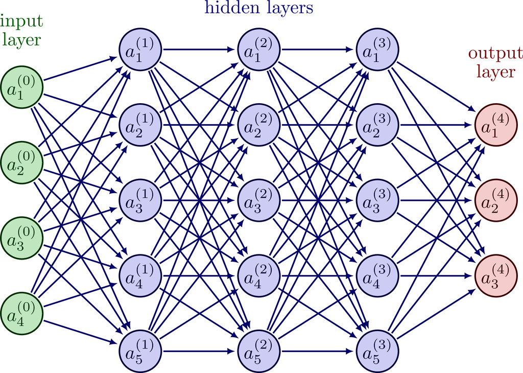

Neural Networks (image source: https://tikz.net)

```r
NN_Model <- caret::train(factor(Loan_Status)~.,
                    data=dataset,
                    method="mlp",
                    tuneGrid = expand.grid(size = 1:10),
                    linOut = T,
                    metric=metric,
                    trControl=evaluationSetting)
print(NN_Model)
```

```
## Multi-Layer Perceptron
##
## 823 samples
##  11 predictor
##   2 classes: '1', '2'
##
## No pre-processing
## Resampling: Cross-Validated (10 fold, repeated 1 times)
## Summary of sample sizes: 741, 740, 740, 741, 741, 740, ...
## Resampling results across tuning parameters:
##
##   size  Accuracy   Kappa      F1         Sensitivity  Specificity
##    1    0.7437702  0.4820180  0.7081662  0.5250000    0.9524363
##    2    0.7666912  0.5295170  0.7080640  0.5935366    0.9318383
##    3    0.7437702  0.4819023  0.7039377  0.5225000    0.9550388
##    4    0.7714370  0.5380410  0.7035007  0.5685976    0.9643411
##    5    0.7080223  0.4166567  0.6901377  0.6685366    0.7454042
##    6    0.7230091  0.4425915  0.7078786  0.5625000    0.8762458
##    7    0.6807376  0.3626014  0.6818472  0.5875000    0.7714286
##    8    0.6525713  0.3038773  0.6341105  0.5525000    0.7490587
##    9    0.7263297  0.4471072  0.7014067  0.5510366    0.8929125
##   10    0.7070526  0.4127355  0.6718208  0.6352439    0.7744186
##   Pos_Pred_Value  Neg_Pred_Value  Precision  Recall     Detection_Rate
##   0.9283646       0.6885196       0.9283646  0.5250000  0.2553923
##   0.9230179       0.7112735       0.9230179  0.5935366  0.2890685
##   0.9300841       0.6899883       0.9300841  0.5225000  0.2541140
##   0.9506340       0.7048556       0.9506340  0.5685976  0.2769615
##   0.8090941       0.7060457       0.8090941  0.6685366  0.3257126
##   0.8793856       0.6878831       0.8793856  0.5625000  0.2736556
##   0.8360906       0.6720403       0.8360906  0.5875000  0.2856450
##   0.7800499       0.6531572       0.7800499  0.5525000  0.2687041
##   0.8705714       0.6907758       0.8705714  0.5510366  0.2684396
##   0.8309796       0.6891361       0.8309796  0.6352439  0.3097708
##   Balanced_Accuracy
##   0.7387182
##   0.7626875
##   0.7387694
##   0.7664693
##   0.7069704
##   0.7193729
##   0.6794643
##   0.6507793
##   0.7219745
##   0.7048313
##
## Accuracy was used to select the optimal model using the largest value.
## The final value used for the model was size = 4.
```

## Random Forest

```r
RF_Model <- caret::train(factor(Loan_Status)~.,
                    data=dataset,
                    method="rf",
                    metric=metric,
                    tuneGrid=expand.grid(.mtry= 7),
                    trControl=evaluationSetting,
                    ntree = 300)
print(RF_Model)
```

```
## Random Forest
##
## 823 samples
##  11 predictor
##   2 classes: '1', '2'
##
## No pre-processing
## Resampling: Cross-Validated (10 fold, repeated 1 times)
## Summary of sample sizes: 741, 741, 740, 740, 741, 741, ...
## Resampling results:
##
##   Accuracy   Kappa      F1         Sensitivity  Specificity  Pos_Pred_Value
##   0.8263297  0.6511717  0.8084859  0.7580488    0.8910853    0.8688992
##   Neg_Pred_Value  Precision  Recall     Detection_Rate  Balanced_Accuracy
##   0.7970668       0.8688992  0.7580488  0.3694387       0.824567
##
## Tuning parameter 'mtry' was held constant at a value of 7
```

## ADABoost

An AdaBoost classifier is a meta-estimator that begins by fitting a classifier on the original dataset and then fits additional copies of the classifier on the same dataset but where the weights of incorrectly classified instances are adjusted such that subsequent classifiers focus more on difficult cases.

```r
ADA_Model <- caret::train(factor(Loan_Status)~.,
                    data=dataset,
                    method="ada",
                    metric=metric,
                    trControl=evaluationSetting,
                    verbose=FALSE)
print(ADA_Model)
```

```
## Boosted Classification Trees
##
## 823 samples
##  11 predictor
##   2 classes: '1', '2'
##
## No pre-processing
## Resampling: Cross-Validated (10 fold, repeated 1 times)
## Summary of sample sizes: 741, 741, 741, 741, 740, 741, ...
## Resampling results across tuning parameters:
##
##   maxdepth  iter  Accuracy   Kappa      F1         Sensitivity  Specificity
##   1          50   0.7740883  0.5427013  0.6974872  0.5538415    0.9833887
##   1         100   0.7740883  0.5427013  0.6974872  0.5538415    0.9833887
##   1         150   0.7740883  0.5427013  0.6974872  0.5538415    0.9833887
##   2          50   0.7814054  0.5580532  0.7160787  0.5863415    0.9667774
##   2         100   0.7837570  0.5634129  0.7287630  0.6137195    0.9453488
##   2         150   0.7923226  0.5811707  0.7470444  0.6436585    0.9335548
##   3          50   0.7837136  0.5638506  0.7378475  0.6360366    0.9239203
##   3         100   0.8007574  0.5986412  0.7642333  0.6709756    0.9240310
##   3         150   0.8068109  0.6110722  0.7742984  0.6884756    0.9192137
##   Pos_Pred_Value  Neg_Pred_Value  Precision  Recall     Detection_Rate
##   0.9691231       0.7034510       0.9691231  0.5538415  0.2698421
##   0.9691231       0.7034510       0.9691231  0.5538415  0.2698421
##   0.9691231       0.7034510       0.9691231  0.5538415  0.2698421
##   0.9454373       0.7164068       0.9454373  0.5863415  0.2856811
##   0.9121785       0.7250190       0.9121785  0.6137195  0.2990082
##   0.9004438       0.7378775       0.9004438  0.6436585  0.3136133
##   0.8890281       0.7313112       0.8890281  0.6360366  0.3099261
##   0.8931967       0.7497216       0.8931967  0.6709756  0.3269262
##   0.8898623       0.7591099       0.8898623  0.6884756  0.3354334
##   Balanced_Accuracy
##   0.7686151
##   0.7686151
##   0.7686151
##   0.7765594
##   0.7795342
##   0.7886067
##   0.7799784
##   0.7975033
##   0.8038447
##
## Tuning parameter 'nu' was held constant at a value of 0.1
## Accuracy was used to select the optimal model using the largest value.
## The final values used for the model were iter = 150, maxdepth = 3 and nu = 0.1.
```

## Gradient Boosting

Gradient boosting is a machine learning technique used in regression and classification tasks, among others. It gives a prediction model in the form of an ensemble of weak prediction models, which are typically decision trees.[1][2] When a decision tree is the weak learner, the resulting algorithm is called gradient-boosted trees; it usually outperforms random forest.[1][2][3] A gradient-boosted trees model is built in a stage-wise fashion as in other boosting methods, but it generalizes the other methods by allowing optimization of an arbitrary differentiable loss function.

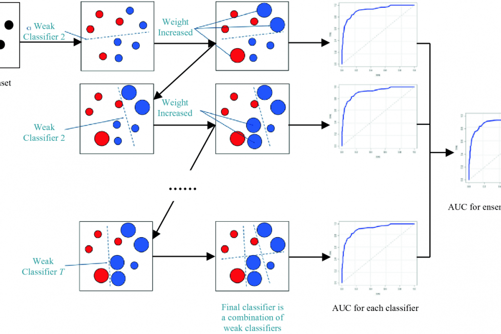

(image source: https://www.tibco.com)

```r
GBM_Model <- caret::train(factor(Loan_Status)~.,
                    data=dataset,
                    method="gbm",
                    metric=metric,
                    #tuneGrid=expand.grid(.mtry= 7),
                    trControl=evaluationSetting,
                    verbose=FALSE)
print(GBM_Model)
```

```
## Stochastic Gradient Boosting
##
## 823 samples
##  11 predictor
##   2 classes: '1', '2'
##
## No pre-processing
## Resampling: Cross-Validated (10 fold, repeated 1 times)
## Summary of sample sizes: 741, 740, 740, 741, 741, 741, ...
## Resampling results across tuning parameters:
##
##   interaction.depth  n.trees  Accuracy   Kappa      F1         Sensitivity
##   1                   50      0.7958272  0.5877103  0.7403170  0.6110976
##   1                  100      0.7861299  0.5688859  0.7388922  0.6311585
##   1                  150      0.8092418  0.6159137  0.7733682  0.6785976
##   2                   50      0.7958566  0.5887036  0.7547445  0.6559756
##   2                  100      0.8080223  0.6138740  0.7793284  0.7007927
##   2                  150      0.7982662  0.5943787  0.7688305  0.6958537
##   3                   50      0.7909932  0.5791828  0.7525143  0.6585976
##   3                  100      0.8043491  0.6063592  0.7740712  0.6982317
##   3                  150      0.8165001  0.6311774  0.7916231  0.7257927
##   Specificity  Pos_Pred_Value  Neg_Pred_Value  Precision  Recall
##   0.9717608    0.9546832       0.7277198       0.9546832  0.6110976
##   0.9338317    0.9038962       0.7297979       0.9038962  0.6311585
##   0.9338317    0.9080654       0.7564478       0.9080654  0.6785976
##   0.9291251    0.9007414       0.7426875       0.9007414  0.6559756
##   0.9101883    0.8838587       0.7636857       0.8838587  0.7007927
##   0.8959579    0.8675545       0.7586777       0.8675545  0.6958537
##   0.9172204    0.8872685       0.7406278       0.8872685  0.6585976
##   0.9053710    0.8739542       0.7624253       0.8739542  0.6982317
##   0.9030454    0.8781492       0.7793747       0.8781492  0.7257927
##   Detection_Rate  Balanced_Accuracy
##   0.2976051       0.7914292
##   0.3073612       0.7824951
##   0.3304731       0.8062146
##   0.3195122       0.7925504
##   0.3413900       0.8054905
##   0.3389362       0.7959058
##   0.3207611       0.7879090
##   0.3401851       0.8018013
##   0.3535410       0.8144190
##
## Tuning parameter 'shrinkage' was held constant at a value of 0.1
##
## Tuning parameter 'n.minobsinnode' was held constant at a value of 10
## Accuracy was used to select the optimal model using the largest value.
## The final values used for the model were n.trees = 150, interaction.depth =
##  3, shrinkage = 0.1 and n.minobsinnode = 10.
```

## LogitBoost

LogitBoost is a boosting classification algorithm. LogitBoost and AdaBoost are close to each other in the sense that both perform an additive logistic regression. The difference is that AdaBoost minimizes the exponential loss, whereas LogitBoost minimizes the logistic loss.

```r
LB_Model <- caret::train(factor(Loan_Status)~.,
                    data=dataset,
                    method="LogitBoost",
                    metric=metric,
                    trControl=evaluationSetting,
                    verbose=FALSE)
print(LB_Model)
```

```
## Boosted Logistic Regression
##
## 823 samples
##  11 predictor
##   2 classes: '1', '2'
##
## No pre-processing
## Resampling: Cross-Validated (10 fold, repeated 1 times)
## Summary of sample sizes: 741, 741, 740, 741, 741, 741, ...
## Resampling results across tuning parameters:
##
##   nIter  Accuracy   Kappa      F1         Sensitivity  Specificity
##   11     0.7642815  0.5263632  0.7363173  0.6757927    0.8484496
##   21     0.7533941  0.5040710  0.7195619  0.6484756    0.8531008
##   31     0.7739348  0.5460297  0.7502695  0.6956707    0.8483389
##   Pos_Pred_Value  Neg_Pred_Value  Precision  Recall     Detection_Rate
##   0.8161024       0.7344307       0.8161024  0.6757927  0.3292830
##   0.8156032       0.7189364       0.8156032  0.6484756  0.3160153
##   0.8212335       0.7464512       0.8212335  0.6956707  0.3389656
##   Balanced_Accuracy
##   0.7621211
##   0.7507882
##   0.7720048
##
## Accuracy was used to select the optimal model using the largest value.
## The final value used for the model was nIter = 31.
```

```r
# Bandingkan kinerja model menggunakan resample()
models_compare <- resamples(list(DecisionTree = DT_Model,
                                 LogisticRegression = RegLog_Model,
                                 SupportVectorMachine = SVM_Model,
                                 NaiveBayes = NB_Model,
                                 NeuralNetworks = NN_Model,
                                 RandomForest = RF_Model,
                                 ADABoost = ADA_Model,
                                 GradienBoosting = GBM_Model,
                                 LogitBoost = LB_Model
                                 ))

# Ringkasan models performances
summary(models_compare)
```

```
##
## Call:
## summary.resamples(object = models_compare)
##
## Models: DecisionTree, LogisticRegression, SupportVectorMachine, NaiveBayes, NeuralNetworks, RandomForest, ADABoost, GradienBoosting, LogitBoost
## Number of resamples: 10
##
## Accuracy
##                           Min.   1st Qu.    Median      Mean   3rd Qu.
## DecisionTree         0.7439024 0.7591463 0.7696885 0.7788128 0.7902953
## LogisticRegression   0.7073171 0.7500000 0.7804878 0.7728916 0.8018293
## SupportVectorMachine 0.7073171 0.7811490 0.7879077 0.7922274 0.8237584
## NaiveBayes           0.7439024 0.7696719 0.7804878 0.7921914 0.8140244
## NeuralNetworks       0.7073171 0.7256098 0.7743902 0.7714370 0.8012048
## RandomForest         0.7590361 0.8079268 0.8242727 0.8263297 0.8308110
## ADABoost             0.6951220 0.7754791 0.8048780 0.8068109 0.8567073
## GradienBoosting      0.7317073 0.7804878 0.8192771 0.8165001 0.8480752
## LogitBoost           0.6829268 0.7682927 0.7818836 0.7739348 0.8042169
##                           Max. NA's
## DecisionTree         0.8292683    0
## LogisticRegression   0.8170732    0
## SupportVectorMachine 0.8536585    0
## NaiveBayes           0.8554217    0
## NeuralNetworks       0.8536585    0
## RandomForest         0.8902439    0
## ADABoost             0.8780488    0
## GradienBoosting      0.8780488    0
## LogitBoost           0.8170732    0
##
## Balanced_Accuracy
##                           Min.   1st Qu.    Median      Mean   3rd Qu.
## DecisionTree         0.7375000 0.7555060 0.7648602 0.7744080 0.7850395
## LogisticRegression   0.7023810 0.7437479 0.7764881 0.7690066 0.7983631
## SupportVectorMachine 0.7017857 0.7767546 0.7850319 0.7879505 0.8196325
## NaiveBayes           0.7375000 0.7642318 0.7750000 0.7873275 0.8104167
## NeuralNetworks       0.7005952 0.7227679 0.7693452 0.7664693 0.7957760
## RandomForest         0.7561047 0.8050595 0.8219823 0.8245670 0.8303317
## ADABoost             0.6910714 0.7716922 0.8017857 0.8038447 0.8538690
## GradienBoosting      0.7267857 0.7785714 0.8172572 0.8144190 0.8466154
## LogitBoost           0.6821429 0.7662583 0.7791667 0.7720048 0.8029305
```

[output cut: 173 more lines]

```
## NeuralNetworks       0.7857143 0.9583333 0.9883721 0.9643411 1.0000000
## RandomForest         0.8333333 0.8809524 0.8928571 0.8910853 0.9231728
## ADABoost             0.8571429 0.8928571 0.9285714 0.9192137 0.9298173
## GradienBoosting      0.8333333 0.8637874 0.9285714 0.9030454 0.9285714
## LogitBoost           0.7142857 0.7985880 0.8707087 0.8483389 0.8809524
##                           Max. NA's
## DecisionTree         1.0000000    0
## LogisticRegression   0.9761905    0
## SupportVectorMachine 1.0000000    0
## NaiveBayes           1.0000000    0
## NeuralNetworks       1.0000000    0
## RandomForest         0.9285714    0
## ADABoost             1.0000000    0
## GradienBoosting      0.9523810    0
## LogitBoost           0.9761905    0
```

# 4.2 Modelling

## Decision Tree

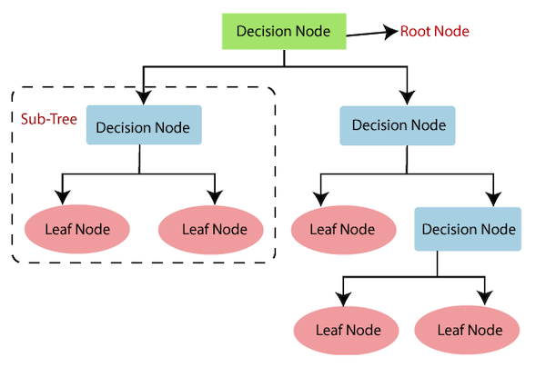

Decision Tree (image source: https://glints.com)

Classification and Regression Tree (CART)

```r
DT_Model2 <- caret::train(factor(Loan_Status)~.,
                    data=dataset2,
                    method="rpart",
                    # metric=metric,
                    # tuneGrid = expand.grid(cp = seq(0, 0.1, 0.001)),
                    # parms = list(split='information'),
                    trControl=evaluationSetting)
print(DT_Model2)
```

```
## CART
##
## 823 samples
##   4 predictor
##   2 classes: '1', '2'
##
## No pre-processing
## Resampling: Cross-Validated (10 fold, repeated 1 times)
## Summary of sample sizes: 739, 741, 741, 741, 740, 741, ...
## Resampling results across tuning parameters:
##
##   cp           Accuracy   Kappa      F1         Sensitivity  Specificity
##   0.006234414  0.7485090  0.4935631  0.7029917  0.6134146    0.8770210
##   0.008728180  0.7569578  0.5099625  0.7042199  0.6009756    0.9052602
##   0.536159601  0.6270941  0.2386868  0.6531814  0.2500000    0.9857697
##   Pos_Pred_Value  Neg_Pred_Value  Precision  Recall     Detection_Rate
##   0.8387848       0.7060938       0.8387848  0.6134146  0.2988777
##   0.8730320       0.7072429       0.8730320  0.6009756  0.2928092
##   0.9435862       0.5922135       0.9435862  0.2500000  0.1216427
##   Balanced_Accuracy
##   0.7452178
##   0.7531179
##   0.6178848
##
## Accuracy was used to select the optimal model using the largest value.
## The final value used for the model was cp = 0.00872818.
```

## Logistic Regression

```r
RegLog_Model2 <- caret::train(factor(Loan_Status)~.,
                    data=dataset2,
                    method="glm",
                    family = 'binomial',
                    # metric=metric,
                    trControl=evaluationSetting)
print(RegLog_Model2)
```

```
## Generalized Linear Model
##
## 823 samples
##   4 predictor
##   2 classes: '1', '2'
##
## No pre-processing
## Resampling: Cross-Validated (10 fold, repeated 1 times)
## Summary of sample sizes: 740, 741, 741, 741, 741, 741, ...
## Resampling results:
##
##   Accuracy   Kappa      F1         Sensitivity  Specificity  Pos_Pred_Value
##   0.7751396  0.5453396  0.7018768  0.5564634    0.9833887    0.9718599
##   Neg_Pred_Value  Precision  Recall     Detection_Rate  Balanced_Accuracy
##   0.702764        0.9718599  0.5564634  0.270908        0.7699261
```

## Support Vector Machine (SVM)

```r
SVM_Model2 <- caret::train(factor(Loan_Status)~.,
                    data=dataset2,
                    method="svmRadial",
                    # metric=metric,
                    trControl=evaluationSetting)
print(SVM_Model2)
```

```
## Support Vector Machines with Radial Basis Function Kernel
##
## 823 samples
##   4 predictor
##   2 classes: '1', '2'
##
## No pre-processing
## Resampling: Cross-Validated (10 fold, repeated 1 times)
## Summary of sample sizes: 741, 740, 741, 741, 741, 741, ...
## Resampling results across tuning parameters:
##
##   C     Accuracy   Kappa      F1         Sensitivity  Specificity
##   0.25  0.7691526  0.5331060  0.6987916  0.5562195    0.9715393
##   0.50  0.7764259  0.5480824  0.7123337  0.5761585    0.9667774
##   1.00  0.7800407  0.5558035  0.7234909  0.5960976    0.9548726
##   Pos_Pred_Value  Neg_Pred_Value  Precision  Recall     Detection_Rate
##   0.9486052       0.6989068       0.9486052  0.5562195  0.2710035
##   0.9435789       0.7079519       0.9435789  0.5761585  0.2807159
##   0.9279411       0.7147251       0.9279411  0.5960976  0.2904283
##   Balanced_Accuracy
##   0.7638794
##   0.7714680
##   0.7754851
##
## Tuning parameter 'sigma' was held constant at a value of 0.6051427
## Accuracy was used to select the optimal model using the largest value.
## The final values used for the model were sigma = 0.6051427 and C = 1.
```

## Naive Bayes

```r
NB_Model2 <- caret::train(factor(Loan_Status)~.,
                    data=dataset2,
                    method="naive_bayes",
                    # metric=metric,
                    trControl=evaluationSetting)
print(NB_Model2)
```

```
## Naive Bayes
##
## 823 samples
##   4 predictor
##   2 classes: '1', '2'
##
## No pre-processing
## Resampling: Cross-Validated (10 fold, repeated 1 times)
## Summary of sample sizes: 741, 741, 740, 740, 741, 741, ...
## Resampling results across tuning parameters:
##
##   usekernel  Accuracy   Kappa      F1         Sensitivity  Specificity
##   FALSE      0.7739201  0.5428607  0.7006239  0.5539634    0.9833887
##    TRUE      0.7787981  0.5528879  0.7109687  0.5664024    0.9810078
##   Pos_Pred_Value  Neg_Pred_Value  Precision  Recall     Detection_Rate
##   0.9702903       0.7013843       0.9702903  0.5539634  0.2696885
##   0.9663919       0.7060679       0.9663919  0.5664024  0.2757861
##   Balanced_Accuracy
##   0.7686761
##   0.7737051
##
## Tuning parameter 'laplace' was held constant at a value of 0
## Tuning
##  parameter 'adjust' was held constant at a value of 1
## Accuracy was used to select the optimal model using the largest value.
## The final values used for the model were laplace = 0, usekernel = TRUE
##  and adjust = 1.
```

## Support Vector Machine (SVM)

```r
SVM_Model2 <- caret::train(factor(Loan_Status)~.,
                    data=dataset2,
                    method="svmRadial",
                    # metric=metric,
                    trControl=evaluationSetting)
print(SVM_Model2)
```

```
## Support Vector Machines with Radial Basis Function Kernel
##
## 823 samples
##   4 predictor
##   2 classes: '1', '2'
##
## No pre-processing
## Resampling: Cross-Validated (10 fold, repeated 1 times)
## Summary of sample sizes: 739, 740, 741, 741, 741, 741, ...
## Resampling results across tuning parameters:
##
##   C     Accuracy   Kappa      F1         Sensitivity  Specificity
##   0.25  0.7680209  0.5307114  0.6978084  0.5561585    0.9692137
##   0.50  0.7777623  0.5507415  0.7155829  0.5811585    0.9644518
##   1.00  0.7862695  0.5682800  0.7313956  0.6036585    0.9596899
##   Pos_Pred_Value  Neg_Pred_Value  Precision  Recall     Detection_Rate
##   0.9467297       0.6985069       0.9467297  0.5561585  0.2710480
##   0.9416400       0.7100286       0.9416400  0.5811585  0.2832284
##   0.9357734       0.7201654       0.9357734  0.6036585  0.2941746
##   Balanced_Accuracy
##   0.7626861
##   0.7728052
##   0.7816742
##
## Tuning parameter 'sigma' was held constant at a value of 0.6425878
## Accuracy was used to select the optimal model using the largest value.
## The final values used for the model were sigma = 0.6425878 and C = 1.
```

## Naive Bayes

```r
NB_Model2 <- caret::train(factor(Loan_Status)~.,
                    data=dataset2,
                    method="naive_bayes",
                    # metric=metric,
                    trControl=evaluationSetting)
print(NB_Model2)
```

```
## Naive Bayes
##
## 823 samples
##   4 predictor
##   2 classes: '1', '2'
##
## No pre-processing
## Resampling: Cross-Validated (10 fold, repeated 1 times)
## Summary of sample sizes: 741, 741, 741, 741, 741, 741, ...
## Resampling results across tuning parameters:
##
##   usekernel  Accuracy   Kappa      F1         Sensitivity  Specificity
##   FALSE      0.7739788  0.5424319  0.7013237  0.5533537    0.9833887
##    TRUE      0.7788128  0.5522599  0.7092821  0.5656707    0.9810078
##   Pos_Pred_Value  Neg_Pred_Value  Precision  Recall     Detection_Rate
##   0.9703394       0.7003977       0.9703394  0.5533537  0.2697326
##   0.9673406       0.7066354       0.9673406  0.5656707  0.2757861
##   Balanced_Accuracy
##   0.7683712
##   0.7733392
##
## Tuning parameter 'laplace' was held constant at a value of 0
## Tuning
##  parameter 'adjust' was held constant at a value of 1
## Accuracy was used to select the optimal model using the largest value.
## The final values used for the model were laplace = 0, usekernel = TRUE
##  and adjust = 1.
```

## Neural Networks (NN)

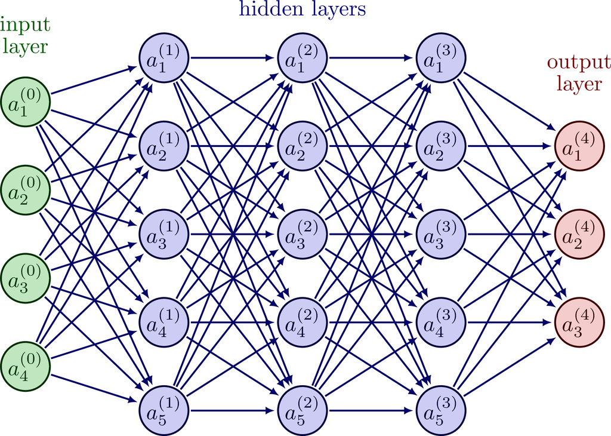

Neural Networks (image source: https://tikz.net)

```r
NN_Model2 <- caret::train(factor(Loan_Status)~.,
                    data=dataset2,
                    method="mlp",
                    tuneGrid = expand.grid(size = 1:10),
                    linOut = T,
                    metric=metric,
                    trControl=evaluationSetting)
print(NN_Model2)
```

```
## Multi-Layer Perceptron
##
## 823 samples
##   4 predictor
##   2 classes: '1', '2'
##
## No pre-processing
## Resampling: Cross-Validated (10 fold, repeated 1 times)
## Summary of sample sizes: 740, 739, 741, 741, 741, 741, ...
## Resampling results across tuning parameters:
##
##   size  Accuracy   Kappa      F1         Sensitivity  Specificity
##    1    0.7740026  0.5425991  0.7029899  0.5534756    0.9834441
##    2    0.7630270  0.5201661  0.6840414  0.5334756    0.9810631
##    3    0.7715636  0.5377275  0.7007783  0.5534756    0.9786822
##    4    0.7740026  0.5426614  0.7040449  0.5559756    0.9810631
##    5    0.7471734  0.4916606  0.6988264  0.5984756    0.8882060
##    6    0.7666856  0.5287887  0.7057873  0.5784756    0.9453488
##    7    0.7715636  0.5378430  0.7027087  0.5584756    0.9739203
##    8    0.7776612  0.5506564  0.7178088  0.5884756    0.9572536
##    9    0.7740026  0.5426464  0.7037029  0.5559756    0.9810631
##   10    0.7715489  0.5379170  0.7038315  0.5609756    0.9715393
##   Pos_Pred_Value  Neg_Pred_Value  Precision  Recall     Detection_Rate
##   0.9681845       0.6995843       0.9681845  0.5534756  0.2697560
##   0.9641990       0.6902808       0.9641990  0.5334756  0.2599999
##   0.9605178       0.6985558       0.9605178  0.5534756  0.2697560
##   0.9646232       0.7002078       0.9646232  0.5559756  0.2709755
##   0.9181845       0.7295083       0.9181845  0.5984756  0.2917072
##   0.9371674       0.7047317       0.9371674  0.5784756  0.2819511
##   0.9531396       0.6998904       0.9531396  0.5584756  0.2721951
##   0.9348833       0.7121548       0.9348833  0.5884756  0.2868292
##   0.9648878       0.7004440       0.9648878  0.5559756  0.2709755
##   0.9512381       0.7005643       0.9512381  0.5609756  0.2733999
##   Balanced_Accuracy
##   0.7684598
##   0.7572694
##   0.7660789
##   0.7685194
##   0.7433408
##   0.7619122
##   0.7661979
##   0.7728646
##   0.7685194
##   0.7662575
##
## Accuracy was used to select the optimal model using the largest value.
## The final value used for the model was size = 8.
```

## Random Forest

```r
RF_Model2 <- caret::train(factor(Loan_Status)~.,
                    data=dataset2,
                    method="rf",
                    metric=metric,
                    tuneGrid=expand.grid(.mtry= 7),
                    trControl=evaluationSetting,
                    ntree = 300)
print(RF_Model2)
```

```
## Random Forest
##
## 823 samples
##   4 predictor
##   2 classes: '1', '2'
##
## No pre-processing
## Resampling: Cross-Validated (10 fold, repeated 1 times)
## Summary of sample sizes: 741, 741, 741, 740, 740, 741, ...
## Resampling results:
##
##   Accuracy   Kappa      F1         Sensitivity  Specificity  Pos_Pred_Value
##   0.7886277  0.5759261  0.7707507  0.7334146    0.841196     0.8147588
##   Neg_Pred_Value  Precision  Recall     Detection_Rate  Balanced_Accuracy
##   0.7705609       0.8147588  0.7334146  0.3573024       0.7873053
##
## Tuning parameter 'mtry' was held constant at a value of 7
```

## ADABoost

An AdaBoost classifier is a meta-estimator that begins by fitting a classifier on the original dataset and then fits additional copies of the classifier on the same dataset but where the weights of incorrectly classified instances are adjusted such that subsequent classifiers focus more on difficult cases.

```r
ADA_Model2 <- caret::train(factor(Loan_Status)~.,
                    data=dataset2,
                    method="ada",
                    metric=metric,
                    trControl=evaluationSetting,
                    verbose=FALSE)
print(ADA_Model2)
```

```
## Boosted Classification Trees
##
## 823 samples
##   4 predictor
##   2 classes: '1', '2'
##
## No pre-processing
## Resampling: Cross-Validated (10 fold, repeated 1 times)
## Summary of sample sizes: 741, 741, 741, 741, 741, 740, ...
## Resampling results across tuning parameters:
##
##   maxdepth  iter  Accuracy   Kappa      F1         Sensitivity  Specificity
##   1          50   0.7739495  0.5428460  0.7013931  0.5537805    0.9834994
##   1         100   0.7739495  0.5428460  0.7013931  0.5537805    0.9834994
##   1         150   0.7739495  0.5428460  0.7013931  0.5537805    0.9834994
##   2          50   0.7739348  0.5429222  0.7027573  0.5587805    0.9787375
##   2         100   0.7812225  0.5579985  0.7179916  0.5812195    0.9716501
##   2         150   0.7824420  0.5605026  0.7203294  0.5837195    0.9716501
##   3          50   0.7812518  0.5582103  0.7201230  0.5862805    0.9669435
##   3         100   0.7824713  0.5611068  0.7282827  0.6062805    0.9503322
##   3         150   0.7824860  0.5613073  0.7312285  0.6137195    0.9433001
##   Pos_Pred_Value  Neg_Pred_Value  Precision  Recall     Detection_Rate
##   0.9715469       0.7008210       0.9715469  0.5537805  0.2696591
##   0.9715469       0.7008210       0.9715469  0.5537805  0.2696591
##   0.9715469       0.7008210       0.9715469  0.5537805  0.2696591
##   0.9629836       0.7024571       0.9629836  0.5587805  0.2720835
##   0.9538285       0.7118177       0.9538285  0.5812195  0.2830150
##   0.9538285       0.7128594       0.9538285  0.5837195  0.2842345
##   0.9458983       0.7131456       0.9458983  0.5862805  0.2854687
##   0.9231322       0.7197208       0.9231322  0.6062805  0.2952101
##   0.9156053       0.7217837       0.9156053  0.6137195  0.2988540
##   Balanced_Accuracy
##   0.7686400
##   0.7686400
##   0.7686400
##   0.7687590
##   0.7764348
##   0.7776848
##   0.7766120
##   0.7783064
##   0.7785098
##
## Tuning parameter 'nu' was held constant at a value of 0.1
## Accuracy was used to select the optimal model using the largest value.
## The final values used for the model were iter = 150, maxdepth = 3 and nu = 0.1.
```

## Gradient Boosting

Gradient boosting is a machine learning technique used in regression and classification tasks, among others. It gives a prediction model in the form of an ensemble of weak prediction models, which are typically decision trees.[1][2] When a decision tree is the weak learner, the resulting algorithm is called gradient-boosted trees; it usually outperforms random forest.[1][2][3] A gradient-boosted trees model is built in a stage-wise fashion as in other boosting methods, but it generalizes the other methods by allowing optimization of an arbitrary differentiable loss function.

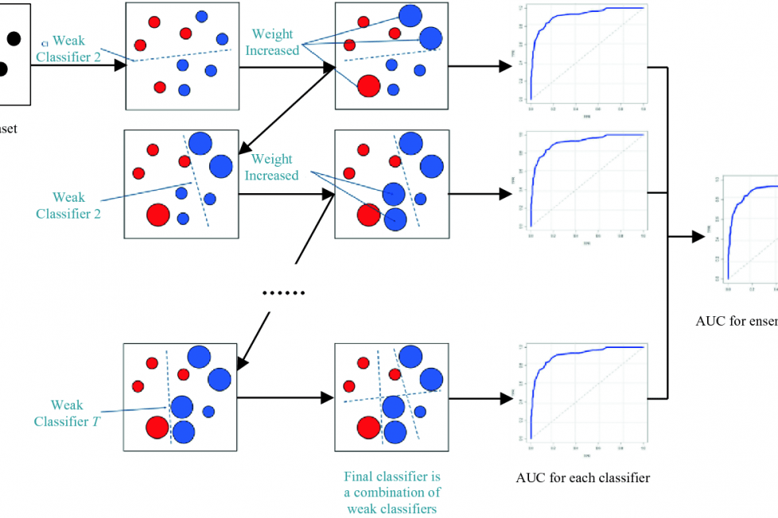

(image source: https://www.tibco.com)

```r
GBM_Model2 <- caret::train(factor(Loan_Status)~.,
                    data=dataset2,
                    method="gbm",
                    metric=metric,
                    #tuneGrid=expand.grid(.mtry= 7),
                    trControl=evaluationSetting,
                    verbose=FALSE)
print(GBM_Model2)
```

```
## Stochastic Gradient Boosting
##
## 823 samples
##   4 predictor
##   2 classes: '1', '2'
##
## No pre-processing
## Resampling: Cross-Validated (10 fold, repeated 1 times)
## Summary of sample sizes: 740, 741, 741, 741, 740, 741, ...
## Resampling results across tuning parameters:
##
##   interaction.depth  n.trees  Accuracy   Kappa      F1         Sensitivity
##   1                   50      0.7750955  0.5453223  0.7067772  0.5612195
##   1                  100      0.7799295  0.5553181  0.7172540  0.5785976
##   1                  150      0.7787100  0.5530927  0.7198640  0.5885366
##   2                   50      0.7811490  0.5577855  0.7189843  0.5810366
##   2                  100      0.7811049  0.5585182  0.7323070  0.6207927
##   2                  150      0.7810608  0.5587371  0.7376298  0.6380488
##   3                   50      0.7896562  0.5753448  0.7368767  0.6108537
##   3                  100      0.7860123  0.5689036  0.7460144  0.6506707
##   3                  150      0.7835439  0.5644967  0.7507419  0.6755488
##   Specificity  Pos_Pred_Value  Neg_Pred_Value  Precision  Recall
##   0.9786268    0.9612754       0.7024419       0.9612754  0.5612195
##   0.9714839    0.9508153       0.7095127       0.9508153  0.5785976
##   0.9596346    0.9348535       0.7117812       0.9348535  0.5885366
##   0.9715947    0.9513250       0.7109930       0.9513250  0.5810366
##   0.9336102    0.9005439       0.7232796       0.9005439  0.6207927
##   0.9169435    0.8821649       0.7292081       0.8821649  0.6380488
##   0.9596899    0.9354823       0.7234751       0.9354823  0.6108537
##   0.9145626    0.8831467       0.7355192       0.8831467  0.6506707
##   0.8861573    0.8502455       0.7440567       0.8502455  0.6755488
##   Detection_Rate  Balanced_Accuracy
##   0.2733030       0.7699232
##   0.2817955       0.7750408
##   0.2866588       0.7740856
##   0.2829856       0.7763156
##   0.3024096       0.7772014
##   0.3108875       0.7774962
##   0.2975757       0.7852718
##   0.3170291       0.7826167
##   0.3291507       0.7808530
##
## Tuning parameter 'shrinkage' was held constant at a value of 0.1
##
## Tuning parameter 'n.minobsinnode' was held constant at a value of 10
## Accuracy was used to select the optimal model using the largest value.
## The final values used for the model were n.trees = 50, interaction.depth =
##  3, shrinkage = 0.1 and n.minobsinnode = 10.
```

## LogitBoost

LogitBoost is a boosting classification algorithm. LogitBoost and AdaBoost are close to each other in the sense that both perform an additive logistic regression. The difference is that AdaBoost minimizes the exponential loss, whereas LogitBoost minimizes the logistic loss.

```r
LB_Model2 <- caret::train(factor(Loan_Status)~.,
                    data=dataset2,
                    method="LogitBoost",
                    metric=metric,
                    trControl=evaluationSetting,
                    verbose=FALSE)
print(LB_Model2)
```

```
## Boosted Logistic Regression
##
## 823 samples
##   4 predictor
##   2 classes: '1', '2'
##
## No pre-processing
## Resampling: Cross-Validated (10 fold, repeated 1 times)
## Summary of sample sizes: 741, 741, 740, 741, 741, 740, ...
## Resampling results across tuning parameters:
##
##   nIter  Accuracy   Kappa      F1         Sensitivity  Specificity
##   11     0.7483691  0.4942702  0.7149339  0.6484756    0.8435770
##   21     0.7909492  0.5796837  0.7632556  0.6957927    0.8811739
##   31     0.7886424  0.5744362  0.7523312  0.6683537    0.9028239
##   Pos_Pred_Value  Neg_Pred_Value  Precision  Recall     Detection_Rate
##   0.8073360       0.7173377       0.8073360  0.6484756  0.3158684
##   0.8630662       0.7573146       0.8630662  0.6957927  0.3390979
##   0.8739824       0.7444852       0.8739824  0.6683537  0.3256685
##   Balanced_Accuracy
##   0.7460263
##   0.7884833
##   0.7855888
##
## Accuracy was used to select the optimal model using the largest value.
## The final value used for the model was nIter = 21.
```

```r
# Bandingkan kinerja model menggunakan resample()
models_compare2 <- resamples(list(DecisionTree2 = DT_Model2,
                                 LogisticRegression2 = RegLog_Model2,
                                 SupportVectorMachine2 = SVM_Model2,
                                 NaiveBayes2 = NB_Model2,
                                 NeuralNetworks2 = NN_Model2,
                                 RandomForest2 = RF_Model2,
                                 ADABoost2 = ADA_Model2,
                                 GradienBoosting2 = GBM_Model2,
                                 LogitBoost2 = LB_Model2
                                 ))

# Ringkasan models performances
summary(models_compare2)
```

```
##
## Call:
## summary.resamples(object = models_compare2)
##
## Models: DecisionTree2, LogisticRegression2, SupportVectorMachine2, NaiveBayes2, NeuralNetworks2, RandomForest2, ADABoost2, GradienBoosting2, LogitBoost2
## Number of resamples: 10
##
## Accuracy
##                            Min.   1st Qu.    Median      Mean   3rd Qu.
## DecisionTree2         0.7195122 0.7439024 0.7515428 0.7569578 0.7682927
## LogisticRegression2   0.6951220 0.7500000 0.7682927 0.7751396 0.8201220
## SupportVectorMachine2 0.7439024 0.7568322 0.7804878 0.7862695 0.8140244
## NaiveBayes2           0.6951220 0.7804878 0.7804878 0.7788128 0.7945563
## NeuralNetworks2       0.6987952 0.7591463 0.7804878 0.7776612 0.8083624
## RandomForest2         0.7195122 0.7628563 0.7939318 0.7886277 0.8140244
## ADABoost2             0.7349398 0.7560976 0.7804878 0.7824860 0.8024537
## GradienBoosting2      0.7439024 0.7682927 0.7804878 0.7896562 0.8102410
## LogitBoost2           0.7195122 0.7835366 0.7951807 0.7909492 0.8048780
##                            Max. NA's
## DecisionTree2         0.8170732    0
## LogisticRegression2   0.8433735    0
## SupportVectorMachine2 0.8536585    0
## NaiveBayes2           0.8554217    0
## NeuralNetworks2       0.8170732    0
## RandomForest2         0.8414634    0
## ADABoost2             0.8313253    0
## GradienBoosting2      0.8795181    0
## LogitBoost2           0.8313253    0
##
## Balanced_Accuracy
##                            Min.   1st Qu.    Median      Mean   3rd Qu.
## DecisionTree2         0.7130952 0.7392546 0.7467262 0.7531179 0.7663690
## LogisticRegression2   0.6875000 0.7443452 0.7636905 0.7699261 0.8156250
## SupportVectorMachine2 0.7392857 0.7509517 0.7764881 0.7816742 0.8095238
## NaiveBayes2           0.6880952 0.7751488 0.7761905 0.7733392 0.7881541
## NeuralNetworks2       0.6892442 0.7534226 0.7779762 0.7728646 0.8038073
## RandomForest2         0.7178571 0.7615656 0.7914659 0.7873053 0.8135417
## ADABoost2             0.7322880 0.7520833 0.7758929 0.7785098 0.7979651
## GradienBoosting2      0.7380952 0.7638393 0.7755952 0.7852718 0.8074267
## LogitBoost2           0.7190476 0.7807932 0.7907530 0.7884833 0.8049107
```

[output cut: 193 more lines]

```
## NeuralNetworks2       0.8333333 0.9523810 0.9648394 0.9572536 0.9940476
## RandomForest2         0.7857143 0.8187984 0.8333333 0.8411960 0.8571429
## ADABoost2             0.8809524 0.9289867 0.9523810 0.9433001 0.9702381
## GradienBoosting2      0.9285714 0.9357697 0.9523810 0.9596899 0.9761905
## LogitBoost2           0.7380952 0.8273810 0.8809524 0.8811739 0.9534884
##                            Max. NA's
## DecisionTree2         1.0000000    0
## LogisticRegression2   1.0000000    0
## SupportVectorMachine2 1.0000000    0
## NaiveBayes2           1.0000000    0
## NeuralNetworks2       1.0000000    0
## RandomForest2         0.9047619    0
## ADABoost2             1.0000000    0
## GradienBoosting2      1.0000000    0
## LogitBoost2           1.0000000    0
```

# 5. Evaluasi

```r
models_compares <- resamples(list(DecisionTree = DT_Model,
                                  DecisionTree2 = DT_Model2,
                                 LogisticRegression = RegLog_Model,
                                 LogisticRegression2 = RegLog_Model2,
                                 SupportVectorMachine = SVM_Model,
                                 SupportVectorMachine2 = SVM_Model2,
                                 NaiveBayes = NB_Model,
                                 NaiveBayes2 = NB_Model2,
                                 NeuralNetworks = NN_Model,
                                 NeuralNetworks2 = NN_Model2,
                                 RandomForest = RF_Model,
                                 RandomForest2 = RF_Model2,
                                 ADABoost = ADA_Model,
                                 ADABoost2 = ADA_Model2,
                                 GradienBoosting = GBM_Model,
                                 GradienBoosting2 = GBM_Model2,
                                 LogitBoost = LB_Model,
                                 LogitBoost2 = LB_Model2
                                 ))

# Ringkasan models performances
summary(models_compares)
```

```
##
## Call:
## summary.resamples(object = models_compares)
##
## Models: DecisionTree, DecisionTree2, LogisticRegression, LogisticRegression2, SupportVectorMachine, SupportVectorMachine2, NaiveBayes, NaiveBayes2, NeuralNetworks, NeuralNetworks2, RandomForest, RandomForest2, ADABoost, ADABoost2, GradienBoosting, GradienBoosting2, LogitBoost, LogitBoost2
## Number of resamples: 10
##
## Accuracy
##                            Min.   1st Qu.    Median      Mean   3rd Qu.
## DecisionTree          0.7439024 0.7591463 0.7696885 0.7788128 0.7902953
## DecisionTree2         0.7195122 0.7439024 0.7515428 0.7569578 0.7682927
## LogisticRegression    0.7073171 0.7500000 0.7804878 0.7728916 0.8018293
## LogisticRegression2   0.6951220 0.7500000 0.7682927 0.7751396 0.8201220
## SupportVectorMachine  0.7073171 0.7811490 0.7879077 0.7922274 0.8237584
## SupportVectorMachine2 0.7439024 0.7568322 0.7804878 0.7862695 0.8140244
## NaiveBayes            0.7439024 0.7696719 0.7804878 0.7921914 0.8140244
## NaiveBayes2           0.6951220 0.7804878 0.7804878 0.7788128 0.7945563
## NeuralNetworks        0.7073171 0.7256098 0.7743902 0.7714370 0.8012048
## NeuralNetworks2       0.6987952 0.7591463 0.7804878 0.7776612 0.8083624
## RandomForest          0.7590361 0.8079268 0.8242727 0.8263297 0.8308110
## RandomForest2         0.7195122 0.7628563 0.7939318 0.7886277 0.8140244
## ADABoost              0.6951220 0.7754791 0.8048780 0.8068109 0.8567073
## ADABoost2             0.7349398 0.7560976 0.7804878 0.7824860 0.8024537
## GradienBoosting       0.7317073 0.7804878 0.8192771 0.8165001 0.8480752
## GradienBoosting2      0.7439024 0.7682927 0.7804878 0.7896562 0.8102410
## LogitBoost            0.6829268 0.7682927 0.7818836 0.7739348 0.8042169
## LogitBoost2           0.7195122 0.7835366 0.7951807 0.7909492 0.8048780
##                            Max. NA's
## DecisionTree          0.8292683    0
## DecisionTree2         0.8170732    0
## LogisticRegression    0.8170732    0
## LogisticRegression2   0.8433735    0
## SupportVectorMachine  0.8536585    0
## SupportVectorMachine2 0.8536585    0
## NaiveBayes            0.8554217    0
## NaiveBayes2           0.8554217    0
## NeuralNetworks        0.8536585    0
## NeuralNetworks2       0.8170732    0
## RandomForest          0.8902439    0
## RandomForest2         0.8414634    0
```

[output cut: 391 more lines]

```
## LogisticRegression2   1.0000000    0
## SupportVectorMachine  1.0000000    0
## SupportVectorMachine2 1.0000000    0
## NaiveBayes            1.0000000    0
## NaiveBayes2           1.0000000    0
## NeuralNetworks        1.0000000    0
## NeuralNetworks2       1.0000000    0
## RandomForest          0.9285714    0
## RandomForest2         0.9047619    0
## ADABoost              1.0000000    0
## ADABoost2             1.0000000    0
## GradienBoosting       0.9523810    0
## GradienBoosting2      1.0000000    0
## LogitBoost            0.9761905    0
## LogitBoost2           1.0000000    0
```